# Benzín

**Dáta v súbore Benzin2000.txt predstavujú ceny benzínu na Slovensku týždenne počas 48 týždňov v roku 2000.**

**Úloha:** Nájdite model pre daný ČR a urobte predikciu pre posledné 4 týždne roku 2000.

#### Načítanie a zobrazenie dát

```r
Benzin2000 <- read.table("Benzin2000.txt", quote="\"", comment.char="")
str(Benzin2000)
```

```
## 'data.frame':    48 obs. of  1 variable:
##  $ V1: num  31.6 30.5 30.7 31.6 31.6 32 32.1 32.1 32.1 32.6 ...
```

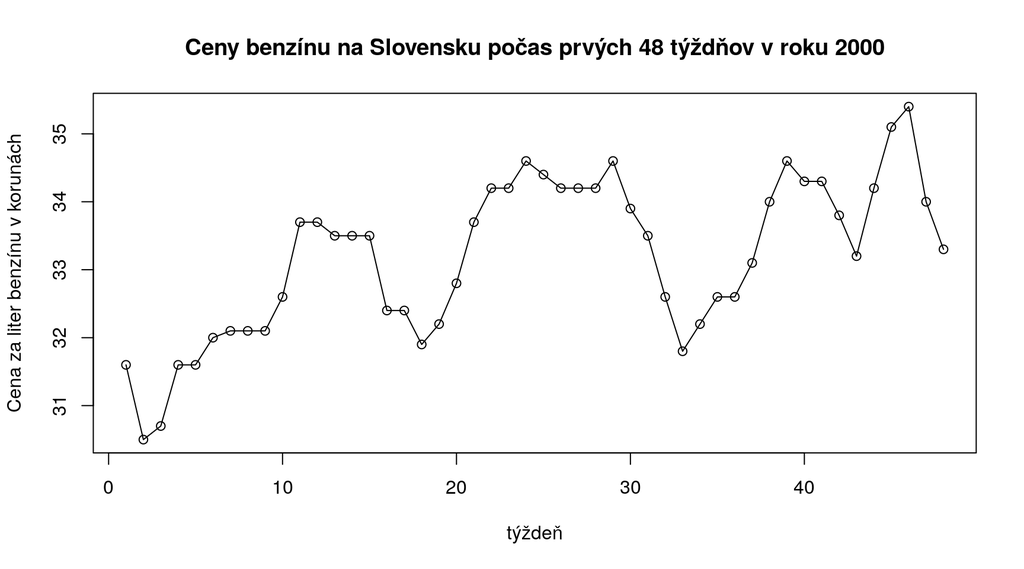

```r
benzin<-Benzin2000$V1
cas<-1:48
plot(cas,benzin, type="o", main = "Ceny benzínu na Slovensku počas prvých 48 týždňov v roku 2000", xlab = "týždeň", ylab = "Cena za liter benzínu v korunách")
```

#### Pozorovanie

- rastúci trend
- sezónna zložka
- ustálená variabilita

#### Nájdenie rovnice lineárneho trendu a jeho odstránenie

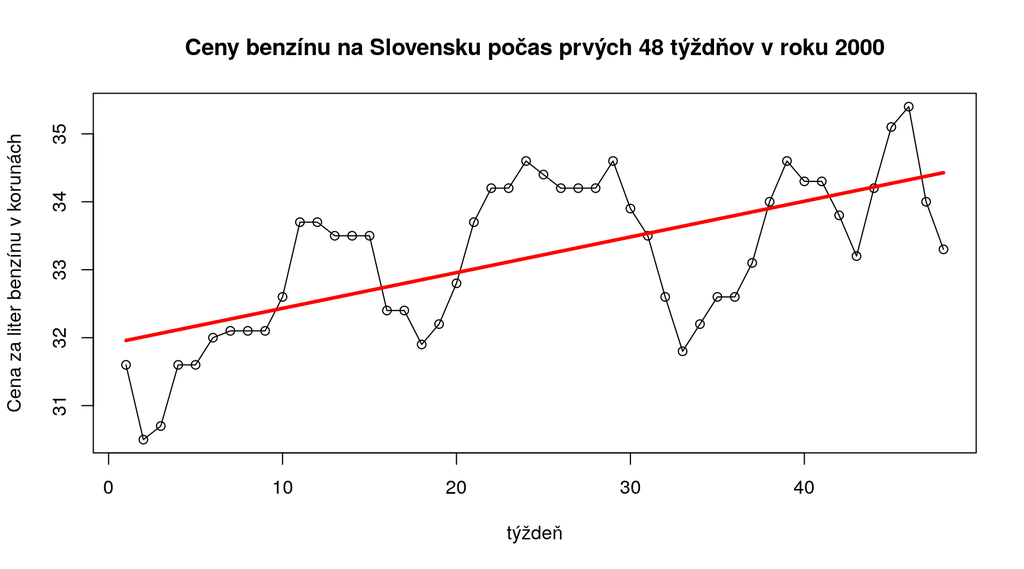

```r
trend<-lm(benzin~cas)
plot(cas,benzin, type="o", main = "Ceny benzínu na Slovensku počas prvých 48 týždňov v roku 2000", xlab = "týždeň", ylab = "Cena za liter benzínu v korunách")
lines(cas, predict(trend), col="red", lwd=3)
```

```r
summary(trend)
```

```
##
## Call:
## lm(formula = benzin ~ cas)
##
## Residuals:
##      Min       1Q   Median       3Q      Max
## -1.84020 -0.60337 -0.09627  0.83657  1.43251
##
## Coefficients:
##              Estimate Std. Error t value Pr(>|t|)
## (Intercept) 31.906915   0.262481 121.559  < 2e-16 ***
## cas          0.052524   0.009326   5.632 1.03e-06 ***
## ---
## Signif. codes:  0 '***' 0.001 '**' 0.01 '*' 0.05 '.' 0.1 ' ' 1
##
## Residual standard error: 0.8951 on 46 degrees of freedom
## Multiple R-squared:  0.4081, Adjusted R-squared:  0.3953
## F-statistic: 31.72 on 1 and 46 DF,  p-value: 1.027e-06
```

Čiastočný model ČR:
$$X(t)=31.9 + 0.05*t+Y(t)$$

Podobjekty premennej “trend” možno tiež zistiť príkazom names():

```r
names(trend)
```

```
##  [1] "coefficients"  "residuals"     "effects"       "rank"
##  [5] "fitted.values" "assign"        "qr"            "df.residual"
##  [9] "xlevels"       "call"          "terms"         "model"
```

#### Analýza reziduí

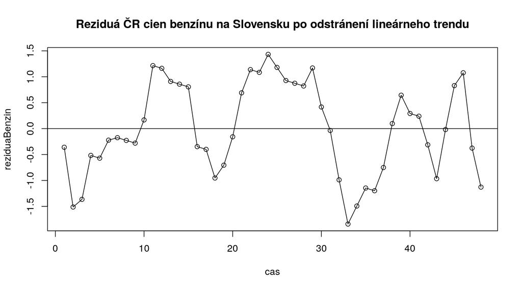

```r
reziduaBenzin<-residuals(trend)
plot(cas, reziduaBenzin, type="o", main = "Reziduá ČR cien benzínu na Slovensku po odstránení lineárneho trendu")
abline(0,0)
```

Reziduá ešte určite sú závislé, bude tam nejaká sezónnosť. Môžeme sa pozrieť na ACF a PACF.

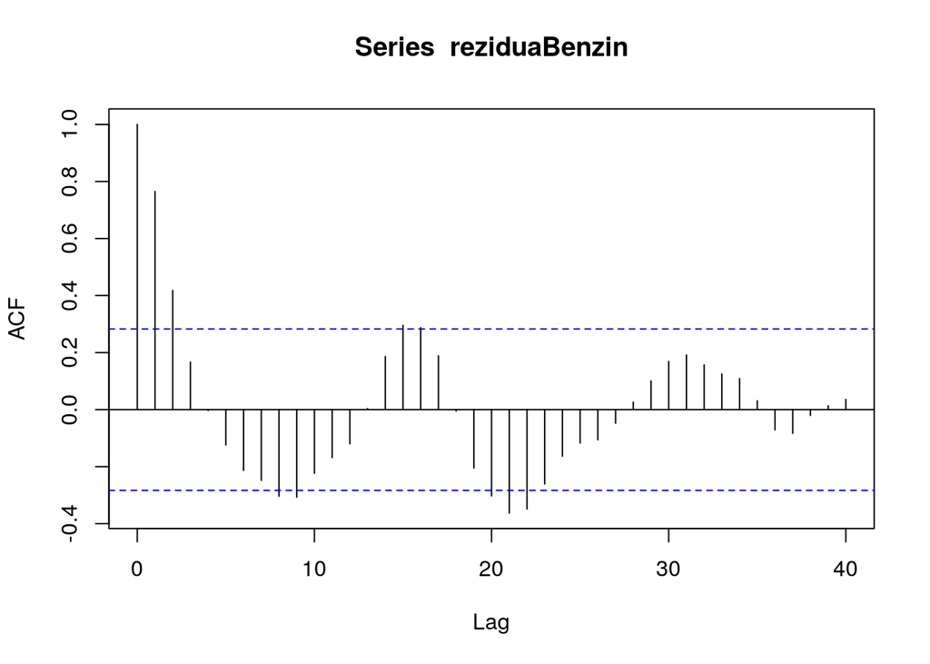

```r
acf(reziduaBenzin,40)
```

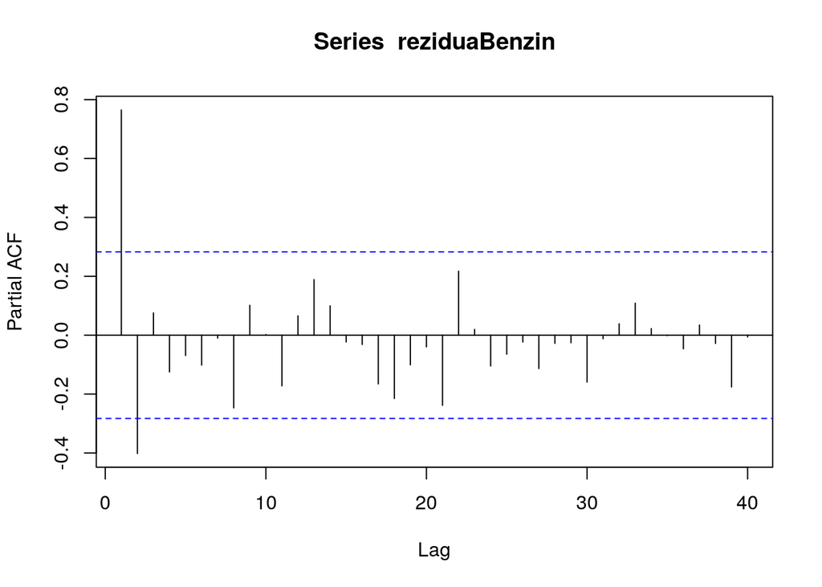

```r
pacf(reziduaBenzin,40)
```

Potrebujeme zistiť významnú frekvenciu - ide sa na periodogram:

```r
periodogram = spec.pgram(reziduaBenzin, log= 'no')
```

[figure not shown]

```r
periodogram
```

```
## $freq
##  [1] 0.02083333 0.04166667 0.06250000 0.08333333 0.10416667 0.12500000
##  [7] 0.14583333 0.16666667 0.18750000 0.20833333 0.22916667 0.25000000
## [13] 0.27083333 0.29166667 0.31250000 0.33333333 0.35416667 0.37500000
## [19] 0.39583333 0.41666667 0.43750000 0.45833333 0.47916667 0.50000000
##
## $spec
##  [1] 2.411350811 1.521278927 7.213786365 1.976990144 0.566752648
##  [6] 2.519976652 0.036825813 0.147864895 0.144907049 0.562493580
## [11] 0.033127291 0.019044619 0.078844518 0.454366809 0.002032719
## [16] 0.027584300 0.013018156 0.003125624 0.075184793 0.041584326
## [21] 0.020797130 0.048928339 0.045428011 0.006888410
##
## $coh
## NULL
##
## $phase
## NULL
##
## $kernel
## NULL
##
## $df
## [1] 1.79159
##
## $bandwidth
## [1] 0.006014065
##
## $n.used
## [1] 48
##
## $orig.n
## [1] 48
##
## $series
## [1] "reziduaBenzin"
##
## $snames
## NULL
##
## $method
## [1] "Raw Periodogram"
##
## $taper
## [1] 0.1
##
## $pad
## [1] 0
##
## $detrend
## [1] TRUE
##
## $demean
## [1] FALSE
##
## attr(,"class")
## [1] "spec"
```

Možeme navrhnúť model:

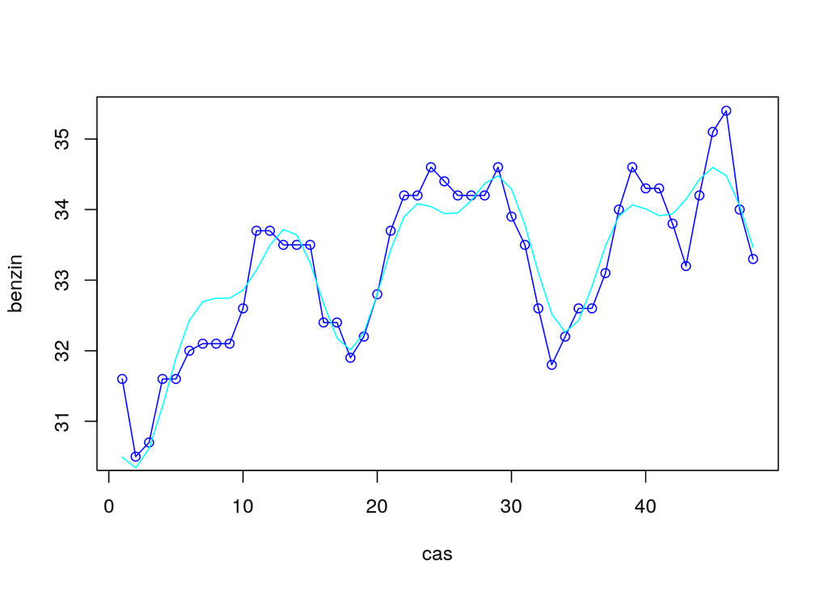

```r
cos1 = cos(2*pi*cas/48)
sin1 = sin(2*pi*cas/48)
cos2 = cos(2*pi*cas*3/48)
sin2 = sin(2*pi*cas*3/48)
cos3 = cos(2*pi*cas*6/48)
sin3 = sin(2*pi*cas*6/48)

ptrend = lm(benzin ~ cas+cos1+sin1+cos2+sin2+cos3+sin3)
plot(cas, benzin, type='o', col= 'blue')
lines(cas, predict(ptrend), col = 'cyan')
```

```r
summary(ptrend)
```

```
##
## Call:
## lm(formula = benzin ~ cas + cos1 + sin1 + cos2 + sin2 + cos3 +
##     sin3)
##
## Residuals:
##      Min       1Q   Median       3Q      Max
## -0.94449 -0.27379 -0.02859  0.25918  1.10643
##
## Coefficients:
##              Estimate Std. Error t value Pr(>|t|)
## (Intercept) 31.925543   0.220321 144.905  < 2e-16 ***
## cas          0.051764   0.008584   6.030 4.29e-07 ***
## cos1        -0.443046   0.093231  -4.752 2.60e-05 ***
## sin1         0.225183   0.160535   1.403    0.168
## cos2        -0.465819   0.093231  -4.996 1.20e-05 ***
## sin2        -0.687315   0.102375  -6.714 4.71e-08 ***
## cos3        -0.034591   0.093231  -0.371    0.713
## sin3        -0.503498   0.095120  -5.293 4.63e-06 ***
## ---
## Signif. codes:  0 '***' 0.001 '**' 0.01 '*' 0.05 '.' 0.1 ' ' 1
##
## Residual standard error: 0.4548 on 40 degrees of freedom
## Multiple R-squared:  0.8671, Adjusted R-squared:  0.8439
## F-statistic: 37.29 on 7 and 40 DF,  p-value: 1.391e-15
```

Ak len jedna konštanta je významná, tak ich necháme v modeli obe - tak to káže Fourierova analýza!

Teraz sa musíme presvedčiť o tom, že reziduá už sú nezávislé.

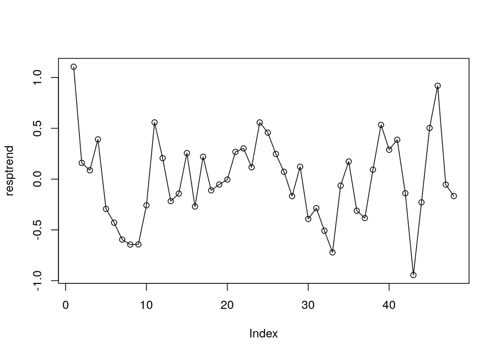

```r
resptrend = residuals(ptrend)
plot(resptrend, type = 'o')
```

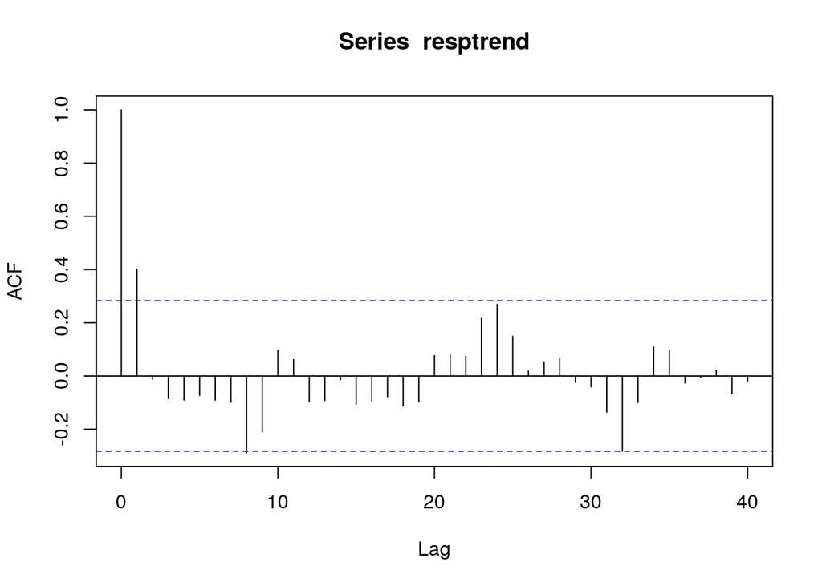

```r
acf(resptrend,40)
```

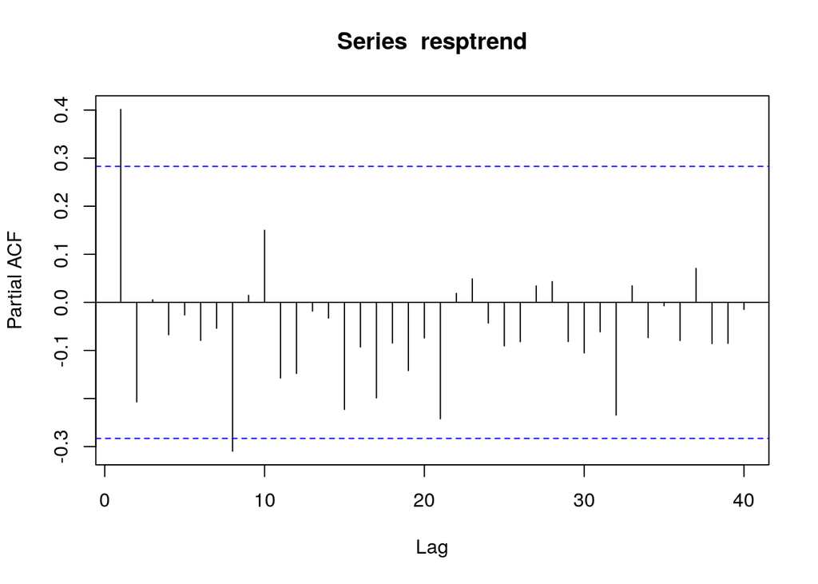

```r
pacf(resptrend,40)
```

```r
Box.test(resptrend)
```

```
##
##  Box-Pierce test
##
## data:  resptrend
## X-squared = 7.7296, df = 1, p-value = 0.005432
```

```r
Box.test(resptrend, type='Ljung')
```

```
##
##  Box-Ljung test
##
## data:  resptrend
## X-squared = 8.223, df = 1, p-value = 0.004136
```

Dáta nie sú úplne nezávislé - acf a pacf naznačujú AR(1) alebo MA(1) - ktorý? Skúsime oba a vezmeme ten, ktorý dáva menšiu sigmu. Otázka znie, že či treba zlepšovať model? Empirické pravidlo je, že nebudeme brať Box test tak vážne a pozrieme sa na Box test s oneskorením.

```r
Box.test(resptrend, lag = 4)
```

```
##
##  Box-Pierce test
##
## data:  resptrend
## X-squared = 8.4773, df = 4, p-value = 0.07558
```

```r
Box.test(resptrend, lag = 4, type= 'Ljung')
```

```
##
##  Box-Ljung test
##
## data:  resptrend
## X-squared = 9.0635, df = 4, p-value = 0.05953
```

Tieto už sú nad hranicou p-value 0.05 a hypotézu nemusíme zamietnuť. Ale pre pokoj v duši ešte môžeme skúsiť tie AR(1), či MA(1)…

```r
AR = ar(resptrend, order = 1, method = 'mle')
AR
```

```
##
## Call:
## ar(x = resptrend, order.max = 1, method = "mle")
##
## Coefficients:
##      1
## 0.4622
##
## Order selected 1  sigma^2 estimated as  0.1396
```

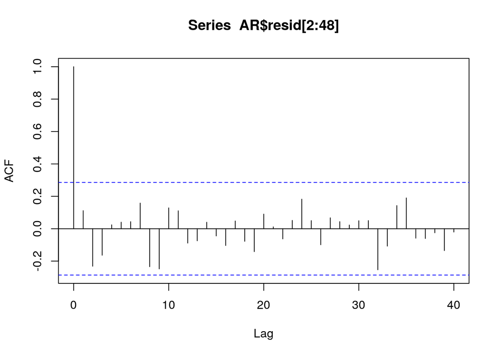

```r
acf(AR$resid[2:48],40)
```

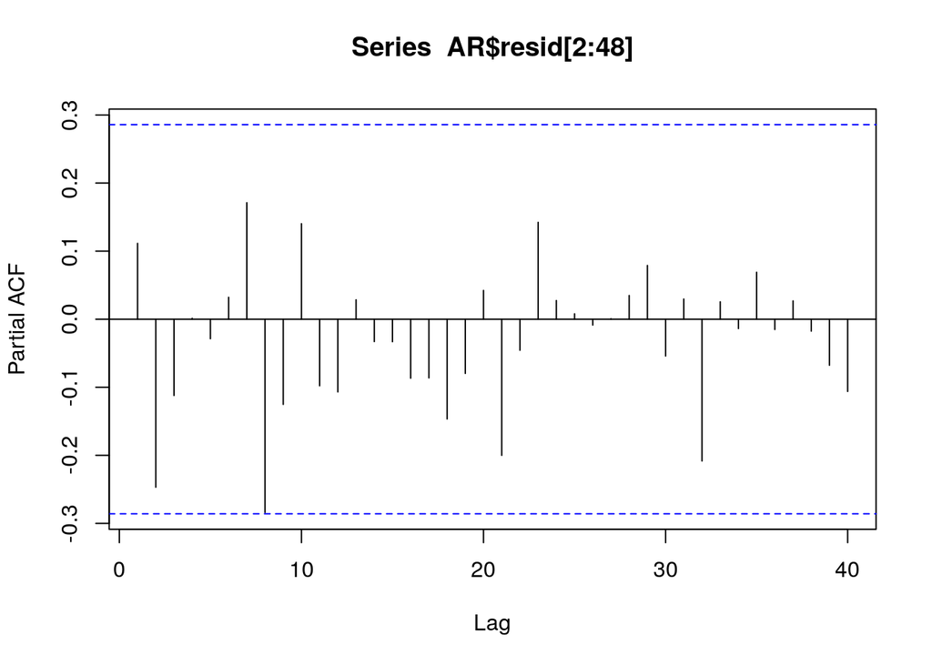

```r
pacf(AR$resid[2:48],40)
```

```r
MA = arima(resptrend, order = c(0,0,1), method = 'ML')
MA
```

```
##
## Call:
## arima(x = resptrend, order = c(0, 0, 1), method = "ML")
##
## Coefficients:
##          ma1  intercept
##       0.5631     0.0121
## s.e.  0.1227     0.0811
##
## sigma^2 estimated as 0.1311:  log likelihood = -19.54,  aic = 45.07
```

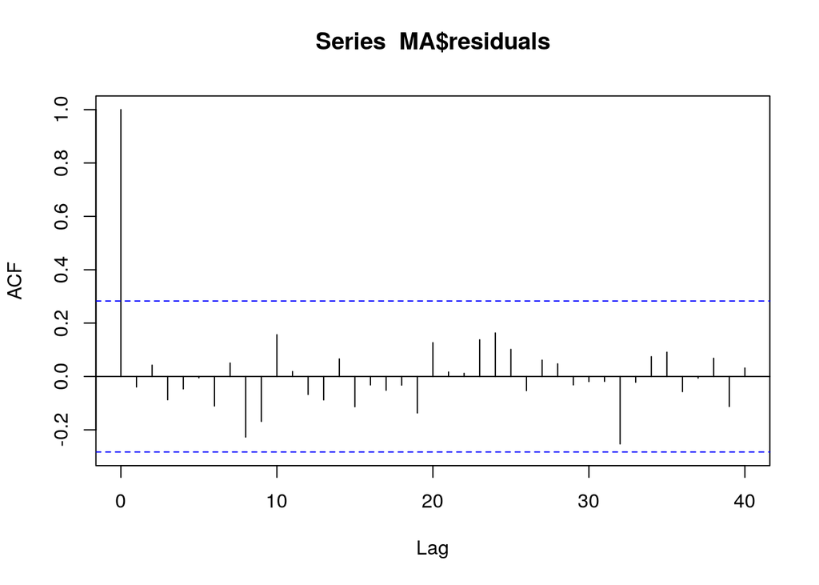

```r
acf(MA$residuals,40)
```

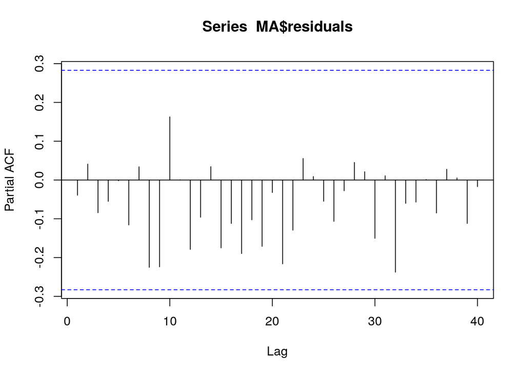

```r
pacf(MA$residuals,40)
```